# Introduction to Data Manipulation in R - PART 1

**Course:** HUDK 4050, Week 3

**Author:** Zhichun Liu

**Assignment:** ICE1

**Objectives:**

1. Install and load packages.
2. Understand data type and structure in R
3. Get started with `tidyverse`

## Install and load packages

At this point, you should have your R and RStudio correctly running. Before we do anything, let me introduce you to your “best friends” – R packages. R community is a very well-maintained community. Many great people have contributed to this community by creating “packages” to enhance the base R functionalities.

Base R is what was originally created by the initial team back in the late 90s. Having a team working on it is great, but a handful of statisticians or computer scientists certainly cannot satisfy the endless and ever-growing needs. That’s why R becomes comprehensive R Archive Network (CRAN), so that everybody can contribute to this open-source project. Different packages are created by different authors for special purposes (e.g., data wrangling, data visualization, modeling, or even self-entertaining). These packages work as add-ons/plug-ins to help us get work done. As of today, the CRAN package repository features more than 18000 available packages.

With that being said, we don’t necessarily need to re-invent the wheels. For the purpose of 4050, you should know how to call the standard packages and correctly use them.

### Install packages

There are multiple ways of installing packages. The most user-friendly way (but a less “cool” way) would be clicking the `install` button on the lower right panel of RStudio:

[figure not shown]

Alternatively, you can try this line below to install a fun package called `beepr`. Notice here, you HAVE TO use the quotation marks `""`.

```r
install.packages("beepr")
```

After successfully calling the command, you then should see the log information rolling up on the screen. It usually should end with `package 'xxx' succussfully unpacked and MD5 sums checked. The downloaded binary packages are in xxxxxxxx`. If you don’t see that, it is likely that the package was not successfully installed because weird dependency issues.

Obviously, there are many more “advance” things in installing R packages such as installing from GitHub or R-Forge, or not-publicly-released packages, or installing multiple packages in one shot, etc. But it is out of the scope of this tutorial, you can read [this article](https://r-coder.com/install-r-packages/), if you are interested in those tricks.

### Loading packages

Once the packages are installed, you can call for their help at any time. However, the installed packages will not load automatically as R starts. You need to `library` them before using:

```r
library(beepr)
# Or library("beepr"). With quotation marks are also fine.
```

You will often see warning messages because many packages are built on old versions of R and you are probably using the latest version. It should not be a problem for 99.5% of the time in 4050.

Once the packages are loaded, you can use the built-in functions. For example, in `beepr`, there is one function called `beepr()`. Let’s call it:

```r
# Beepr(5) will play a sound. Feel free to try beepr(x) where x is any integer from 1 to 11.
beep(5)
```

There are 18000+ packages, so you would imagine that there are some packages accidentally named one of their functions the same. When there are multiple functions with the same name, R will take a guess. To help R avoid confusion, you can do something like this:

```r
beepr::beep(5)
```

`beepr::` declares the `beep()` function belongs to the `beepr` package. You *don’t* have to do that all the time especially when your code is pretty simple.

If you forget how to use a function or want to read the full documentation. You can always use `?`. R will direct you to the user manual.

```r
# check the documentation for beepr package
?beepr
# check the docuementation for beep()
?beep()
```

If you want to check whether a package is successfully loaded, you can either call `(.packages())` or click on the `Global Environment` under the `Environment` tab to check manually.

```r
(.packages())
```

```
## [1] "beepr"     "stats"     "graphics"  "grDevices" "utils"     "datasets"
## [7] "methods"   "base"
```

## Understand data type and structure in R

### Basic data types

You will probably work with three most common data types in R (there are more but we are not going to discuss them here). They are:

- **character**: `"a"`, `"Hello World!"` - this type of data is the nominal data we have discussed in class.
- **numeric**: `2`, `15.5` - this type of data is the numerical data (can be either interval or ratio) we have discussed. In practice, `2` is likely to be stored as `integer`. So don’t be surprised when you see `integer`.
- **logical**: `TRUE`, `FALSE` - this is a special data type because it only takes two values (i.e., `TRUE` or `FALSE` or `0` or `1`). Notice here, `TRUE/FALSE` has to be in ALL CAPS.

R provides many functions to examine features of vectors and other objects, for example, `typeof()` and `length()`. See below (for more information, call `?typeof()` or `?length()`)

```r
# Assigning 1 to 10 to x; so x becomes a vector of 1, 2, 3 ... 10. The default length of step is 1.
x <- 1:10
print(x)
```

```
##  [1]  1  2  3  4  5  6  7  8  9 10
```

```r
typeof(x)
```

```
## [1] "integer"
```

```r
length(x)
```

```
## [1] 10
```

```r
# Feel free to try other values such as number with decimals or characters, or logical values, etc.
```

You might be wondering what about ordinal? Ordinal data are stored as factors in R, which are a special data type. They can store both strings and integers. They are useful in the columns which have a limited number of unique values.

```r
### This is a series of raw data stored in characters
characterData <- c("East","West","East","North","North","East","West","West","West","East","North")
typeof(characterData)
```

```
## [1] "character"
```

```r
print(characterData)
```

```
##  [1] "East"  "West"  "East"  "North" "North" "East"  "West"  "West"  "West"
## [10] "East"  "North"
```

```r
# Apply the factor function to make it a ordinal variable
factor_data <- factor(characterData)
typeof(factor_data)
```

```
## [1] "integer"
```

```r
print(factor_data)
```

```
##  [1] East  West  East  North North East  West  West  West  East  North
## Levels: East North West
```

If you are interested in reading how R stores factor data, read [this](https://www.geeksforgeeks.org/convert-factor-to-numeric-and-numeric-to-factor-in-r-programming/)

### Null-based values

R can store different values in its objects (e.g., character, numeric, integer, logical, complex). I want to introduce a special type of value here: `NA`, `NaN`, `NULL`, and `Inf`. They are all null-based values, which means nothing is there. But they are all different. As for right now, all you need to know is `NA` means *not available* and it is generally used in R language (and a lot of other languages to denote missing values). Please read more here: [R null values: NULL, NA, NaN, Inf](https://www.r-bloggers.com/2018/07/r-null-values-null-na-nan-inf/)

### Data structures

#### Vectors and list

A vector is the most common and basic data structure in R and is pretty much the workhorse of R. Technically, vectors can be one of two types:

- atomic vectors: only stores one type of data
- lists: can store multidimensional data (not often used in the context of basic EDM) although the term “vector” most commonly refers to the atomic types not to lists.

```r
# Creating an atomic vector only with logical values
v <- c(TRUE, TRUE, FALSE, FALSE)
typeof(v)
```

```
## [1] "logical"
```

```r
print(v)
```

```
## [1]  TRUE  TRUE FALSE FALSE
```

```r
# Creating an atomic vector but try to store different data types in it.
v <- c("1", 1, TRUE)
typeof(v) ##R will create a resulting vector with a mode that can most easily accommodate all the elements it contains. This conversion between modes of storage is called “coercion”. When R converts the mode of storage based on its content, it is referred to as “implicit coercion”.
```

```
## [1] "character"
```

```r
print(v)
```

```
## [1] "1"    "1"    "TRUE"
```

```r
# Creating an atomic vector but try to store different data types in it.
l <- list("1", 1, TRUE)
typeof(l) # Notice here it will tell you that this vector is a list.
```

```
## [1] "list"
```

```r
print(l)
```

```
## [[1]]
## [1] "1"
##
## [[2]]
## [1] 1
##
## [[3]]
## [1] TRUE
```

### Matrix and data frame

In R matrices are an extension of the numeric or character vectors. They are not a separate type of object but simply an atomic vector with dimensions; the number of rows and columns. As with atomic vectors, the elements of a matrix must be of the same data type.

```r
m <- matrix(nrow = 3, ncol = 3)
m # by default, the value will be NA
```

```
##      [,1] [,2] [,3]
## [1,]   NA   NA   NA
## [2,]   NA   NA   NA
## [3,]   NA   NA   NA
```

```r
FOURS <- matrix( # Or something like this. Tip: You don't have to write R script in one single line. Sometimes, breaking it will increase the readability.
  c(4, 4, 4, 4), # This is all the data you want to put into the matrix
  nrow = 2, # This tells R the number of rows
  ncol = 2) # This tells R the number of columns
FOURS
```

```
##      [,1] [,2]
## [1,]    4    4
## [2,]    4    4
```

Also try `orderedM <- matrix( c(1, 2, 3, 4), nrow = 2, ncol = 2)` and see how 1, 2, 3, 4 is arranged.

Matrix has a couple of attributes you can check:

```r
# dimension of a matrix
dim(FOURS)
```

```
## [1] 2 2
```

```r
# class of the matrix
class(FOURS)
```

```
## [1] "matrix" "array"
```

```r
# type of data
typeof(FOURS)
```

```
## [1] "double"
```

A data frame is probably the most important data type in R. It’s pretty much the *de facto* data structure for most tabular data and what we use for statistics.

A data frame is a special type of list where every element of the list has same length (i.e. data frame is a “rectangular” list).

Data frames can have additional attributes such as `rownames()`, which can be useful for annotating data, like `subjectID` or `sampleID`. But most of the time they are not used.

Some additional information on data frames:

- Assuming all columns in a data frame are of same type, data frame can be converted to a matrix with data.matrix() (preferred) or as.matrix(). Otherwise type coercion will be enforced and the results may not always be what you expect.
- Can also create a new data frame with `data.frame()` function.
- Find the number of rows and columns with `nrow(df)` and `ncol(df)`, respectively.
- Rownames are often automatically generated and look like 1, 2, …, n. Consistency in numbering of rownames may not be honored when rows are reshuffled or subset.

```r
id <- letters[1:10] #creating the first 10 alphabetic letters
score <- 1:10 # a numeric vector with 10 elements from 1 to 10.
enrolled <- logical(10) # a logical vector with 10 elements. All false

df <- data.frame(id, score, enrolled)
df
```

| id | score | enrolled |
| --- | --- | --- |
| a | 1 | FALSE |
| b | 2 | FALSE |
| c | 3 | FALSE |
| d | 4 | FALSE |
| e | 5 | FALSE |
| f | 6 | FALSE |
| g | 7 | FALSE |
| h | 8 | FALSE |
| i | 9 | FALSE |
| j | 10 | FALSE |

Here are a list of useful data frame functions, you may want to give it a try:

- `head()` - shows first 6 rows
- `tail()` - shows last 6 rows
- `dim()` - returns the dimensions of data frame (i.e. number of rows and number of columns)
- `nrow()` - number of rows
- `ncol()` - number of columns
- `str()` - structure of data frame - name, type and preview of data in each column
- `names()` or `colnames()` - both show the `names` attribute for a data frame
- `sapply(dataframe, class)` - shows the class of each column in the data frame

Here are a couple of more built-in R data (all in the format of data frame)

```r
# The data was extracted from the 1974 Motor Trend US magazine, and comprises fuel consumption and 10 aspects of automobile design and performance for 32 automobiles (1973–74 models)


data("mtcars")

head(mtcars)
```

|  | mpg | cyl | disp | hp | drat | wt | qsec | vs | am | gear | carb |
| --- | --- | --- | --- | --- | --- | --- | --- | --- | --- | --- | --- |
| Mazda RX4 | 21.0 | 6 | 160 | 110 | 3.90 | 2.620 | 16.46 | 0 | 1 | 4 | 4 |
| Mazda RX4 Wag | 21.0 | 6 | 160 | 110 | 3.90 | 2.875 | 17.02 | 0 | 1 | 4 | 4 |
| Datsun 710 | 22.8 | 4 | 108 | 93 | 3.85 | 2.320 | 18.61 | 1 | 1 | 4 | 1 |
| Hornet 4 Drive | 21.4 | 6 | 258 | 110 | 3.08 | 3.215 | 19.44 | 1 | 0 | 3 | 1 |
| Hornet Sportabout | 18.7 | 8 | 360 | 175 | 3.15 | 3.440 | 17.02 | 0 | 0 | 3 | 2 |
| Valiant | 18.1 | 6 | 225 | 105 | 2.76 | 3.460 | 20.22 | 1 | 0 | 3 | 1 |

```r
#iris data set gives the measurements in centimeters of the variables sepal length, sepal width, petal length and petal width, respectively, for 50 flowers from each of 3 species of iris. The species are Iris setosa, versicolor, and virginica.

data("iris")
iris # You can also call the entire dataset. R Notebook is smart enough to build an interactive interface for you to browse around.
```

| Sepal.Length | Sepal.Width | Petal.Length | Petal.Width | Species |
| --- | --- | --- | --- | --- |
| 5.1 | 3.5 | 1.4 | 0.2 | setosa |
| 4.9 | 3.0 | 1.4 | 0.2 | setosa |
| 4.7 | 3.2 | 1.3 | 0.2 | setosa |
| 4.6 | 3.1 | 1.5 | 0.2 | setosa |
| 5.0 | 3.6 | 1.4 | 0.2 | setosa |
| 5.4 | 3.9 | 1.7 | 0.4 | setosa |
| 4.6 | 3.4 | 1.4 | 0.3 | setosa |
| 5.0 | 3.4 | 1.5 | 0.2 | setosa |
| 4.4 | 2.9 | 1.4 | 0.2 | setosa |
| 4.9 | 3.1 | 1.5 | 0.1 | setosa |

[output cut: 140 more lines]

## Get started with `tidyverse`

### Tidy data

As discussed in class, tidy data is a consistent way to organize data in R. Here I want to just show you a very high level practical introduction to tidy data in the `tidyverse` package. If you’d like to learn more about the underlying theory, you might enjoy reading the *Tidy Data paper* published in the Journal of Statistical Software, https://vita.had.co.nz/papers/tidy-data.pdf

You will need to have `tidyverse` successfully installed and loaded. You probably don’t need to install it because it comes with the R Notebook. The first time you create a R Notebook, R Studio will help you install `tidyverse` and its dependencies automatically. But if the following command does not load, you might need to re-install `tidyverse`.

```r
library(tidyverse)
```

### Importing data

Before getting into the weeds of tidy data, we need to talk about reading data into R. It is probably going to be the most common thing to do at the beginning of your code. Importing data into R is fairly simple. The default and preferred file type is `.csv` or `.txt`. For “tidy” syntax, let’s all use `.csv`. Download the `ICE1_Data.csv` from Canvas to your working directory and call `read_csv()`. Don’t forget to assign the result of `read_csv()` to an object, otherwise, it won’t stay in your environment.

This dataset is a subset of performance review data of NYC High Schools

Source: https://data.cityofnewyork.us/d/42et-jh9v Please visit New York City’s open data portal for more information about the Terms of Use.

```r
ICEdata <- read_csv("ICE1_Data.csv")
ICEdata
```

| DBN | Quality_Review_Score | Progress_Rpt_10-11 | Student_Progress_10-11 | graduation 2010-11 | college enroll 2010-11 |
| --- | --- | --- | --- | --- | --- |
| 01M292 | Developing | C | C | 0.563 | 0.519 |
| 01M448 | Developing | C | B | 0.707 | 0.363 |
| 01M450 | Well Developed | A | B | 0.716 | 0.692 |
| 01M509 | Proficient | C | C | 0.564 | 0.477 |
| 01M539 | Proficient | A | A | 0.953 | 0.870 |
| 01M696 | Well Developed | B | C | 0.976 | 0.957 |
| 02M047 | Proficient | C | D | 0.696 | 0.471 |
| 02M288 | Proficient | A | B | 0.820 | 0.627 |
| 02M294 | Well Developed | B | B | 0.675 | 0.483 |
| 02M296 | Proficient | A | A | 0.793 | 0.560 |

[output cut: 412 more lines]

**Side Note**: If your data is not in your working directory, the file will not load. Here are a couple of work-arounds:

- Find out where your working directory is by `getwd()` and move the data file to your working directory manually.
- Change your working directory to where your data is stored `setwd()`. You will need to type your URL in the format R likes: `"C:/Users/liulu/Documents"` or `"C:\\Users\\liulu\\Documents"`. Read more about working directory here: https://support.rstudio.com/hc/en-us/articles/200711843-Working-Directories-and-Workspaces
- Use `choose.dir()` to choose it manually. This will open up a GUI for you to choose. It is probably the most beginner-friendly and straight-forward way. But if you need to run the script multiple times, you might want to still work with the working directories to save time.
- If you want to know more about importing data (including importing `.xlsx` files from Excel or `.sav` files from SPSS), please read this [comprehensive guide to importing data in r](https://www.datacamp.com/community/tutorials/r-data-import-tutorial)

```r
getwd()
ICEdata <- read_csv(choose.dir())
```

### Let’s try some simple data wrangling!

#### Quick-and-dirty summary

The quickest way to know what is going on is to call `summary()`. But it only works well for numerical variables and factors.

```r
summary(ICEdata)
```

```
##      DBN            Quality_Review_Score Progress_Rpt_10-11
##  Length:422         Length:422           Length:422
##  Class :character   Class :character     Class :character
##  Mode  :character   Mode  :character     Mode  :character
##
##
##
##
##  Student_Progress_10-11 graduation 2010-11 college enroll 2010-11
##  Length:422             Min.   :0.4120     Min.   :0.1410
##  Class :character       1st Qu.:0.6252     1st Qu.:0.3910
##  Mode  :character       Median :0.7260     Median :0.4890
##                         Mean   :0.7380     Mean   :0.5312
##                         3rd Qu.:0.8508     3rd Qu.:0.6560
##                         Max.   :1.0000     Max.   :1.0000
##                         NA's   :112        NA's   :131
```

You can try to change all the character variables to factors with (This syntax is a little bit complicated here. We will unpack it later):

```r
ICEdata_factor <- ICEdata %>%
  mutate_if(sapply(ICEdata, is.character), as.factor)
summary(ICEdata_factor)
```

```
##       DBN
##  01M292 :  1
##  01M448 :  1
##  01M450 :  1
##  01M509 :  1
##  01M539 :  1
##  01M696 :  1
##  (Other):416
##                                                                              Quality_Review_Score
##  Developing                                                                            : 64
##  Outstanding (only an option in 2007-8)                                                :  3
##  Proficient                                                                            :186
##  Underdeveloped                                                                        :  6
##  Underdeveloped with Proficient Features (only an option in 2007-8, 2008-9 and 2009-10):  1
##  Well Developed                                                                        :108
##  NA's                                                                                  : 54
##  Progress_Rpt_10-11 Student_Progress_10-11 graduation 2010-11
##  A   :109           A   : 76               Min.   :0.4120
##  B   :102           B   : 91               1st Qu.:0.6252
##  C   : 72           C   : 93               Median :0.7260
##  D   : 22           D   : 35               Mean   :0.7380
##  F   :  5           F   : 15               3rd Qu.:0.8508
##  NA's:112           NA's:112               Max.   :1.0000
##                                            NA's   :112
##  college enroll 2010-11
##  Min.   :0.1410
##  1st Qu.:0.3910
##  Median :0.4890
##  Mean   :0.5312
##  3rd Qu.:0.6560
##  Max.   :1.0000
##  NA's   :131
```

#### Selecting limited number of variables

Sometimes, you don’t need to work with a huge dataset. You just need a handful of variables. You can do something like this

```r
studentProgressGraduation <- # Assigning
  ICEdata_factor %>% # pipeline: this means passing ICEdata_factor to the next command
  select(`Progress_Rpt_10-11`, `graduation 2010-11`) # select two variables named `Progress_Rpt_10-11`, `graduation 2010-11`. Notice here "from the dataset of ICEdata_factor" is implied because of the pipeline.

# Or just write in one line: studentProgressGraduation <- ICEdata_factor %>% select(`Progress_Rpt_10-11`, `graduation 2010-11`)

studentProgressGraduation
```

| Progress_Rpt_10-11 | graduation 2010-11 |
| --- | --- |
| C | 0.563 |
| C | 0.707 |
| A | 0.716 |
| C | 0.564 |
| A | 0.953 |
| B | 0.976 |
| C | 0.696 |
| A | 0.820 |
| B | 0.675 |
| A | 0.793 |

[output cut: 412 more lines]

This is a typical `tidyverse` syntax. `tidyverse` uses `%>%` to indicate pipelines between commands. This is something not easy to understand (especially you are used to the old style of programming), but it will increase the code readability once you get used to it.

Or sometimes, you just need one variable. An easy (and old-school R) way is to use `$` to select one single variable. Type `ICEdata` followed by a `$`, you will receive prompts from R to select variable.

```r
# I am only printing the head of this variable here because we have 400+ values.
graduation201011 <- ICEdata$`graduation 2010-11`
head(graduation201011)
```

```
## [1] 0.563 0.707 0.716 0.564 0.953 0.976
```

Notice here, R uses a `` to mark what a variable is. Normally you don’t have to do that if your variable names do not have space in it. When you name your columns, rows, variables, and sometimes file names, try to avoid using spaces. It adds human-readability but it sometimes messes computer’s brain.

For more style guide, read here: http://adv-r.had.co.nz/Style.html

Once you have a single vector you can do something like, `mean()`, `median()`, or `length()`. Give it a try.

```r
# mean of graduation201011
## You try it:

# median of graduation201011
## You try it:

# length of graduation201011
## Example code here:
length(graduation201011)
```

```
## [1] 422
```

#### Plot something

Next, let’s take a look at plotting. Data visualization is an art so we are not going to spend too much time here. Let’s just figure out the very basic stuff: `plot()` function. This is R’s built-in function and will help you draw simple diagrams based on the type of data you have. Here, I drew a bunch of boxplots with `studentProgressGraduation` data. The reason R decides to plot it like this is because it contains two variables (i.e., Progress_Rpt_10-11 and graduation 2010-11). The former one is a categorical variable and the second one is a continuous variable.

You can try to select other variables and play with `plot()` a little bit.

If you have only one variable, then you might want to try things like `hist()` or `boxplot()`

We will have the last week of this semester to talk about data visualization. So just hang in there.

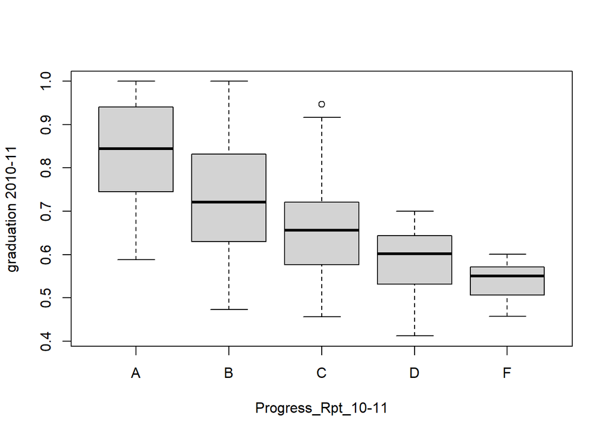

```r
plot(studentProgressGraduation)
```

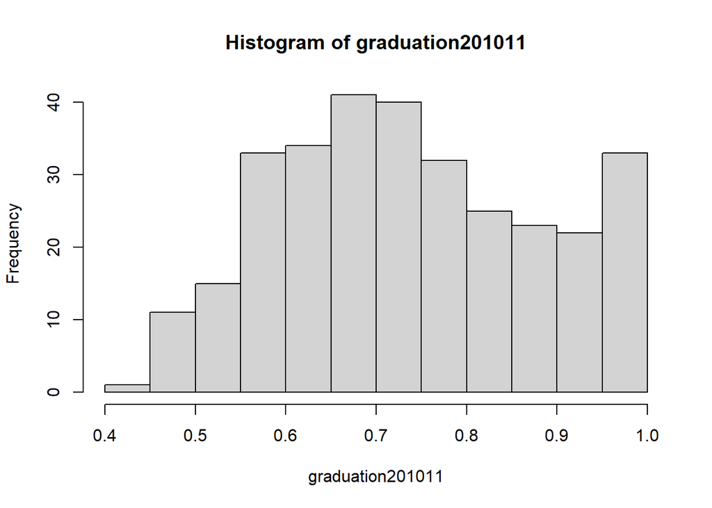

```r
hist(graduation201011)
```

## Your Tasks for ICE 1

For ICE 1, you may want to:

1. follow my tutorial and test install/load packages.
2. try to explore different types of data and structure. You don’t have to follow exactly what I put into the tutorial. Try different things. Don’t worry, you won’t break R.
3. try import the dataset and some simple data manipulation methods (e.g., summary/descriptive stats, variable selection, and plotting)
4. keep good record of your ICEs. Save the .Rmd files in a same place. You will need them later.